# 以勒查经 《交友之道》

12 September, 2020

## 破冰：

[figure not shown]

> - 從小的知己，為什麼是他/她？你們如何維繫友情、保持來往？
> - 有沒有被朋友出賣的經歷、或者出賣朋友的經歷？對方怎樣出賣？

## 箴言中的損友

| 和合本 | ESV |
| --- | --- |
| 箴 1:10-15 我兒，惡人若引誘你，你不可隨從。他們若說：你與我們同去，我們要埋伏流人之血，要蹲伏害無罪之人；我們好像陰間，把他們活活吞下；他們如同下坑的人，被我們囫圇吞了；我們必得各樣寶物，將所擄來的，裝滿房屋；你與我們大家同分，我們共用一個囊袋；我兒，不要與他們同行一道，禁止你腳走他們的路。 | Proverbs 1:10-15 My son, if sinners entice you, do not consent. If they say, “Come with us, let us lie in wait for blood; let us ambush the innocent without reason; like Sheol let us swallow them aliv… |
| 箴 12:26 義人引導他的鄰舍；惡人的道叫人失迷。 | Proverbs 12:26 The righteous is a guide to his neighbor; But the way of the wicked causeth them to err. |
| 箴 13:20 與智慧人同行的，必得智慧；和愚昧人作伴的，必受虧損。 | Proverbs 13:20 Whoever walks with the wise becomes wise, but the companion of fools will suffer harm. |
| 箴 16:19 心裡謙卑與窮乏人來往，強如將擄物與驕傲人同分。 | Proverbs 16:19 It is better to be of a lowly spirit with the poor than to divide the spoil with the proud. |
| 箴 16:28-29 乖僻人播散紛爭；傳舌的，離間密友。強暴人誘惑鄰舍，領他走不善之道 | Proverbs 16:28 A dishonest man spreads strife, and a whisperer separates close friends. A man of violence entices his neighbor and leads him in a way that is not good. |
| 箴 17:9 遮掩人過的，尋求人愛；屢次挑錯的，離間密友。 | Proverbs 17:9 Whoever covers an offense seeks love, but he who repeats a matter separates close friends. |
| 箴 18:24 濫交朋友的，自取敗壞；但有一朋友比弟兄更親密。 | Proverbs 18:24 A man of many companions may come to ruin, but there is a friend who sticks closer than a brother. |
| 箴 20:19 往來傳舌的，洩漏密事；大張嘴的，不可與他結交。 | Proverbs 20:19 Whoever goes about slandering reveals secrets; therefore do not associate with a simple babbler. |
| 箴 22:24-25 好生氣的人，不可與他結交；暴怒的人，不可與他來往； 恐怕你效法他的行為，自己就陷在網羅裡。 | Proverbs 22:24 Make no friendship with a man given to anger, nor go with a wrathful man, lest you learn his ways and entangle yourself in a snare. |
| 箴 23:20-21 好飲酒的，好吃肉的，不要與他們來往；因為好酒貪食的，必致貧窮；好睡覺的，必穿破爛衣服。 | Proverbs 23:20-21 Be not among drunkards[a] or among gluttonous eaters of meat, for the drunkard and the glutton will come to poverty, and slumber will clothe them with rags. |

[output cut: 4 more lines]

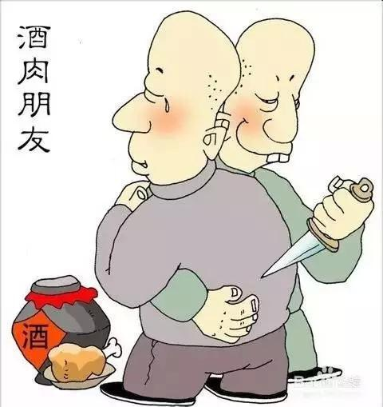

> - 箴言中的損友有什麼特徵？
> - 跟這樣的人來往有什麼後果？你曾否遇到損友的經歷？
> - 神要我們傳福音，難道只跟好人來往，跟他們傳福音？如何遮掩人過才合適？

答案：  
- 特徵：引诱，行暴力、贪财的人，叫人迷失、領人走歪路的人，愚昧人 ， 驕傲人，散播謠言的人，洩漏密事，話癆，好生氣、暴怒的人，好宴樂、享受的人， 反复無常的人  
- 後果：迷失, 受虧損，離開神，會效法他們的行為 ，變為窮光蛋，會有災難臨到，被神毀滅，會被騙  
- 有時候要遮掩人過，也沒涉及社會公益的是，只是個人利益的問題

## 益友的特質

| 和合本 | ESV |
| --- | --- |
| 箴 12:26 義人引導他的鄰舍；惡人的道叫人失迷。 | Proverbs 12:26 The righteous is a guide to his neighbor; But the way of the wicked causeth them to err. |
| 箴 17:9 遮掩人過的，尋求人愛；屢次挑錯的，離間密友。 | Proverbs 17:9 Whoever covers an offense seeks love, but he who repeats a matter separates close friends. |
| 箴 17:17 朋友乃時常親愛，弟兄為患難而生。 | Proverbs 17:17 A friend loves at all times, and a brother is born for adversity. |
| 箴 22:11 喜愛清心的人因他嘴上的恩言，王必與他為友。 | Proverbs 22:11 He who loves purity of heart, and whose speech is gracious, will have the king as his friend. |
| 箴 27:6 朋友加的傷痕出於忠誠；仇敵連連親嘴卻是多餘。 | Proverbs 27:6 Faithful are the wounds of a friend; profuse are the kisses of an enemy. |
| 箴 27:9 膏油與香料使人心喜悅；朋友誠實的勸教也是如此甘美。 | Proverbs 27:9 Oil and perfume make the heart glad, and the sweetness of a friend comes from his earnest counsel. |
| 箴 27:17 鐵磨鐵，磨出刃來；朋友相感（原文是磨朋友的臉）也是如此。 | Proverb 27:17 Iron sharpens iron, and one man sharpens another. |

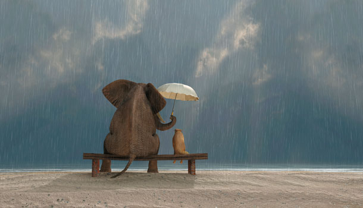

> - 箴言描述了哪些益友的特質？
> - 我們期待良朋益友有什麼素質？我們成為別人的朋友，需要什麼素質？
> - 哪一項對你來說是特別重要的？哪方面你是需要加以改善的？

答案：  
- 益友：敬畏神的人，按神心意生活的人，引導人走正路的人，智慧人，窮乏人  
- 會引導人走正路  
- 不會老是挑別人的錯，原諒別人的過錯  
- 愛朋友，在困難的時候也幫助、不離棄  
- 說恩言  
- 誠實指出朋友的錯，誠實地勸教朋友  
- 互相磨利，把菱角磨平

## 得友之道

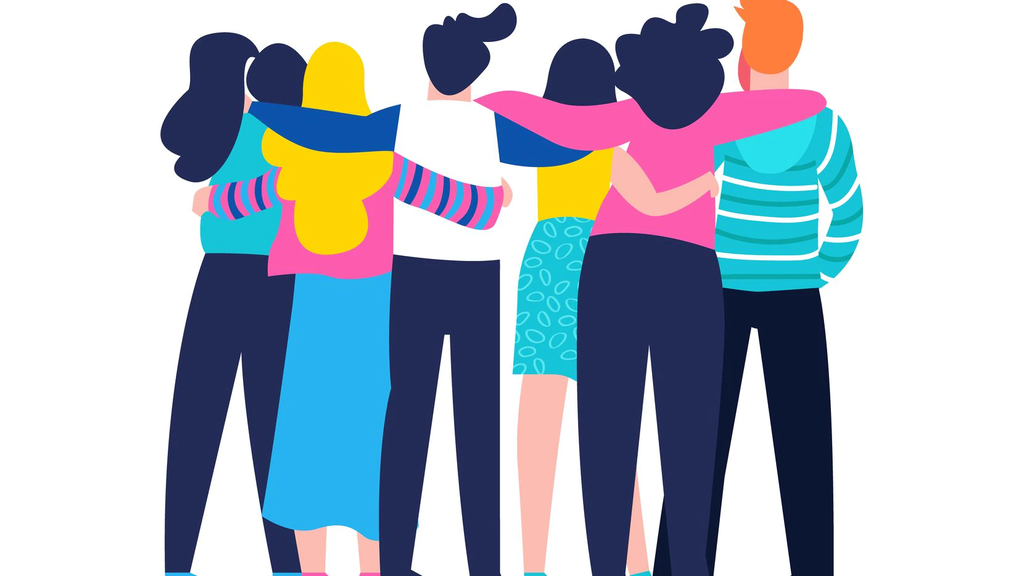

| 和合本 | ESV |
| --- | --- |
| 箴 12:26 義人引導他的鄰舍；惡人的道叫人失迷。 | Proverbs 12:26 The righteous is a guide to his neighbor; But the way of the wicked causeth them to err. |
| 箴 14:20 貧窮人連鄰舍也恨他；富足人朋友最多。 | Proverbs 14:20 The poor is disliked even by his neighbor, but the rich has many friends. |
| 箴 16:19 心裡謙卑與窮乏人來往，強如將擄物與驕傲人同分。 | Proverbs 16:19 It is better to be of a lowly spirit with the poor than to divide the spoil with the proud. |
| 箴 16:28-29 乖僻人播散紛爭；傳舌的，離間密友。強暴人誘惑鄰舍，領他走不善之道 | Proverbs 16:28 A dishonest man spreads strife, and a whisperer separates close friends. A man of violence entices his neighbor and leads him in a way that is not good. |
| 箴 17:9 遮掩人過的，尋求人愛；屢次挑錯的，離間密友。 | Proverbs 17:9 Whoever covers an offense seeks love, but he who repeats a matter separates close friends. |
| 箴 17:17 朋友乃時常親愛，弟兄為患難而生。 | Proverbs 17:17 A friend loves at all times, and a brother is born for adversity. |
| 箴 18:24 濫交朋友的，自取敗壞；但有一朋友比弟兄更親密。 | Proverbs 18:24 A man of many companions may come to ruin, but there is a friend who sticks closer than a brother. |
| 箴 19:4 財物使朋友增多；但窮人朋友遠離。 | Proverbs 19:4 Wealth brings many new friends, but a poor man is deserted by his friend. |
| 箴 19:6 好施散的，有多人求他的恩情；愛送禮的，人都為他的朋友。 | Proverbs 19:6 Many seek the favor of a generous man, and everyone is a friend to a man who gives gifts. |
| 箴 19:7 貧窮人，弟兄都恨他；何況他的朋友，更遠離他！他用言語追隨，他們卻走了。 | Proverbs 19:7 All a poor man's brothers hate him; how much more do his friends go far from him! He pursues them with words, but does not have them. |

[output cut: 6 more lines]

**问题(请点击)**

> - 哪些人會多得到朋友？他們分別得到怎麼樣的朋友？
> - 我們如何才能得到良朋益友，而不是得到豬朋狗友、酒肉朋友？
> - “廣交朋友”跟“濫交朋友”有什麼分別？為什麼濫交朋友會帶來惡果？
> - 箴言教我們怎樣維繫友情？
> - 如何操練遮掩人過？

答案：  
- 有錢人會多有朋友，窮人就沒朋友；這些估計都是損友，為的要是錢  
- 好施捨的人，清心的人，常說恩言的人也多有朋友  
- 以真誠跟人相處，常說恩言，顧及他們的需要

答案：  
- 若跟朋友承諾了不能做的事，要在朋友面前謙卑  
- 要心裡謙卑，願意與地位比他低的人來往  
- 不要散播紛爭，在人背後說閒話  
- 不要濫交朋友，要謹慎選擇人作為好朋友  
- 不要故意祝福朋友讓別人看見、聽見  
- 要跟臨近的人建立朋友關係，困難時就不會缺乏幫助

## 应用问题

> - 新冠疫情對你的交友、跟朋友相處有什麼影響？
> - 如何在疫情中維繫跟朋友的關係，和建立新的友誼？

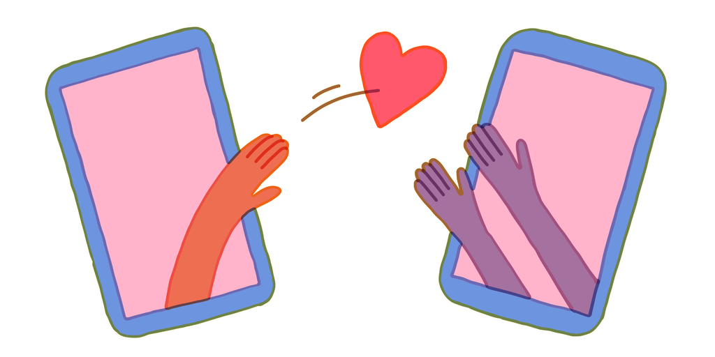

## 结论

> - 不要與惡人為友，包括那些行暴力、散播謠言、話癆、好生氣、與贪财的人，免得自己也走上他們的歪路，自討苦吃。
> - 益友的特質是：誠實地勸教朋友，引導人走正路，不會老是挑錯，在困難的時不離不棄，並且說恩言。讓我們選擇與益友交往,也努力成為別人的益友。
> - 不要濫交朋友;要有智慧地與敬畏神的人做朋友，就能互相的鼓勵、勸勉、扶持、代禱。

## 全部经文

| 和合本 | ESV |
| --- | --- |
| 箴 1:10-15 我兒，惡人若引誘你，你不可隨從。他們若說：你與我們同去，我們要埋伏流人之血，要蹲伏害無罪之人；我們好像陰間，把他們活活吞下；他們如同下坑的人，被我們囫圇吞了；我們必得各樣寶物，將所擄來的，裝滿房屋；你與我們大家同分，我們共用一個囊袋；我兒，不要與他們同行一道，禁止你腳走他們的路。 | Proverbs 1:10-15 My son, if sinners entice you, do not consent. If they say, “Come with us, let us lie in wait for blood; let us ambush the innocent without reason; like Sheol let us swallow them aliv… |
| 箴 6:1-3 我兒，你若為朋友作保，替外人擊掌，你就被口中的話語纏住，被嘴裡的言語捉住。我兒，你既落在朋友手中，就當這樣行才可救自己：你要自卑，去懇求你的朋友。 | Proverbs 6:1-3 My son, if you have put up security for your neighbor, have given your pledge for a stranger, if you are snared in the words of your mouth, caught in the words of your mouth, then do th… |
| 箴 7:21-23 淫婦用許多巧言誘他隨從，用諂媚的嘴逼他同行。少年人立刻跟隨她，好像牛往宰殺之地；又像愚昧人帶鎖鍊去受刑罰，直等箭穿他的肝；如同雀鳥急入網羅，卻不知是自喪己命。 | Proverbs 7:21-23 With much seductive speech she persuades him; with her smooth talk she compels him. All at once he follows her, as an ox goes to the slaughter, or as a stag is caught fast[a] till an … |
| 箴 12:26 義人引導他的鄰舍；惡人的道叫人失迷。 | Proverbs 12:26 The righteous is a guide to his neighbor; But the way of the wicked causeth them to err. |
| 箴 13:20 與智慧人同行的，必得智慧；和愚昧人作伴的，必受虧損。 | Proverbs 13:20 Whoever walks with the wise becomes wise, but the companion of fools will suffer harm. |
| 箴 14:20 貧窮人連鄰舍也恨他；富足人朋友最多。 | Proverbs 14:20 The poor is disliked even by his neighbor, but the rich has many friends. |
| 箴 16:19 心裡謙卑與窮乏人來往，強如將擄物與驕傲人同分。 | Proverbs 16:19 It is better to be of a lowly spirit with the poor than to divide the spoil with the proud. |
| 箴 16:28-29 乖僻人播散紛爭；傳舌的，離間密友。強暴人誘惑鄰舍，領他走不善之道 | Proverbs 16:28 A dishonest man spreads strife, and a whisperer separates close friends. A man of violence entices his neighbor and leads him in a way that is not good. |
| 箴 17:9 遮掩人過的，尋求人愛；屢次挑錯的，離間密友。 | Proverbs 17:9 Whoever covers an offense seeks love, but he who repeats a matter separates close friends. |
| 箴 17:17 朋友乃時常親愛，弟兄為患難而生。 | Proverbs 17:17 A friend loves at all times, and a brother is born for adversity. |

[output cut: 17 more lines]